# Introduction to IPython and Jupyter Notebook

Jupyter notebooks offer a flexible way to combine python (and other language) scripts, text (such as this one), plots, and other things into one document.

There are two modi: command und edit. You enter edit mode by pressing `Enter`. You can exit it by pressing `Esc`. To see the shortcuts for each modus press `Esc` followed by `h`.

If you want a new input above your current cell, press `a` in command mode. If you would like a new cell below your current cell press `b`.

In the course, we'll use the *IPython kernel* within the Jupyter notebook.

## Magic and Help

IPyhon extends the normal Python shell with magic commands. You can get a list of available magic commands using the magic command `%lsmagic`. Give it a try. Use `Shift+Enter` to execute the cell. Just pressing `Enter` only gives you a new line.

```python
%lsmagic
```

Not all the magic commands may be obvious to you, so it's a good thing that IPython also includes a help system. If you want to know, for example, what `%dhist` does im comparison to `%hist`, you call first `%dhist?` and then `%hist?`. Give it a try.

```python
%history?
```

You saw that `%hist` is just an alias for `%history`.

Some of the magic commands, e.g., `%less`, `%ls`, and `%man` are substitutes for their shell equivalents, others, e.g., `%load`, `%save`, `%%writefile` deal with reading and writing from (to) files. We'll encounter more magic commands as we go along.

The question mark doesn't just work for magic functions but gives you access to the documentation included with most Python modules. If you want to know, for example, what the random module does, you use `random?`. Give it a try.

```python
import random
```

If you didn't get the documentation but only `` Object `random` not found ``. Try importing the module first. Start by typing `im` and hit the tab key. Then type `r` and hit tab again. You'll get a dropdown box with available modules. You can continue typing until your choice is unique or select an item from the list. Give it a try.

Try `random?` after importing the module. If you use `??` instead of `?` you get the source code.

```python
random??
```

## Plotting

We won't go into the details of using [matplotlib](http://matplotlib.org/) for plotting in this course, but a quick introduction can't hurt.

We first need to initialize the interactive plotting routines. The easiest way to do this is to use some magic. The command `%pylab inline` sets up interactive plotting and pulls all functions and modules from `numpy` and `matplotlib.pyplot` into the namespace.

Alternatively, the command `%matplotlib inline` sets up interactive plotting support without importing any modules. This allows us to import the modules ourselves.

```python
%pylab inline
```

```python
from numpy import *
import numpy as np
```

```python
from IPython.display import set_matplotlib_formats
set_matplotlib_formats('pdf', 'svg')
```

```python
x = linspace(0, 2 * np.pi, 120)
y = sin(x)
```

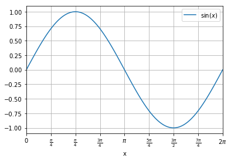

```python
plot(x, y, label=r"$\sin(x)$")
xlim([0, 2 * np.pi])
grid(1)
xticks(np.linspace(0, 2 * np.pi, 9), [0, r"$\frac{\pi}{4}$",
                                          r"$\frac{\pi}{4}$", r"$\frac{3\pi}{4}$", r"$\pi$",
                                          r"$\frac{5\pi}{4}$", r"$\frac{3\pi}{2}$", r"$\frac{7\pi}{4}$"
                                          , r"$2\pi$"])
xlabel('x')
legend()
```